# Essentials of Mathematics and Statistics: Coursework

Author

Student ID: <3143465>

Published

November 14, 2026

## 0.1 AI use statement

# 1 Simulation: The Frog on the Lily Pads

## 1.1 Question 1 (a) Code Comment

```r
#Define function named hop, while input is the initial position, setting up probability of going right as 0.5.
hop <- function(position, p_right = 0.5) {
  #Set up from going either -1 or 1, missing number of trials(size), defined probability going left as 1- 0.5.
  step <- sample(c(-1, 1), prob = c(p_right, 1 - p_right))
  #update the new position
  position + step
  #return function
  return(position)
}
#Testing with calling function hop with value 4 as initial
hop(4)
```

```
[1] 4
```

## 1.2 Question 1 (b) Updating Code

```r
  #setting up initial position in the function
hop <- function(position = 4, p_right = 0.5) {
  #Picking random number from -1 or 1 for next direction, and probability of going right is 0.5, with left as 1-0.5=0.5
  step <- sample(c(-1, 1),
                 size =1,
                 prob = c(1-p_right,p_right))
  #update the new position, name new position as new_position for better tracking
  new_position <- position+ step
  #return function
  return(new_position)
}

hop()
```

```
[1] 3
```

## 1.3 Question 2 Simulating a full game

```r
play_frog()
```

```
$path
 [1] 4 5 6 7 6 7 6 7 6 7 8

$hops
[1] 10

$bank
[1] "right"
```

## 1.4 Question 3(a) Repeated games

```r
#Get result stored into Result_03
results_Q3<- simulate_frogs(n_sims= 1000)

#Display the result of frog_stats
results_Q3$frog_stats
```

```
p_right_bank    mean_hops      sd_hops
     0.49800     15.29800     11.50598
```

## 1.5 Question 3(b) Repeated games CI Calculations

```r
#finding 95% CI and Histogram
nbankr <- sum(results_Q3$banks == "right",na.rm = TRUE)
n_total <- length(results_Q3$banks)
p_right_bank <- nbankr/ n_total
#using binomial testing with nbankr as x and ntotal as y
ci<- binom.test(
  x = nbankr,
  n = n_total,
  conf.level = 0.95
)

lower_ci = ci$conf.int[1]
upper_ci = ci$conf.int[2]

c(p_right_bank = p_right_bank, lower_ci = lower_ci, upper_ci = upper_ci)
```

```
p_right_bank     lower_ci     upper_ci
   0.4980000    0.4665553    0.5294565
```

## 1.6 Question 3(c) Repeated games Histogram Plotting

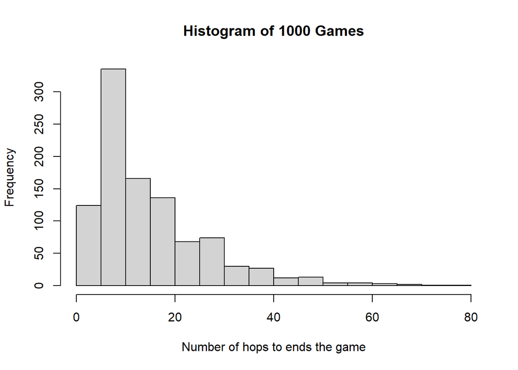

```r
hist(
  results_Q3$hops_vector,
  main = "Histogram of 1000 Games",
  xlab = "Number of hops to ends the game"
)
```

## 1.7 Question 4(a) Changing the starting pad from 1-7

```r
#lets set up value n for startpads from 1-7
n_startpads=1:7
#set up a list for Q4 result for storing the result, or else it wont be recorded
results_Q4= list()
#loop simulate_frogs from n=1 to n=7, and print result after every cycles
for (n in n_startpads){
  results_Q4[[n]] <- simulate_frogs(n_sims = 1000,
                               start = n)
  print(results_Q4[[n]]$frog_stats)
}
```

```
p_right_bank    mean_hops      sd_hops
     0.13300      7.21400     10.31934
p_right_bank    mean_hops      sd_hops
     0.22100     11.49800     11.68763
p_right_bank    mean_hops      sd_hops
     0.37400     14.91600     12.34963
p_right_bank    mean_hops      sd_hops
     0.52200     16.13800     13.04404
p_right_bank    mean_hops      sd_hops
     0.62200     15.11600     13.11757
p_right_bank    mean_hops      sd_hops
     0.74900     11.83600     11.46336
p_right_bank    mean_hops      sd_hops
     0.87200      7.28400     10.55304
```

## 1.8 Question 4(b) Plot the proportion of games ending on the right bank against the starting pad.

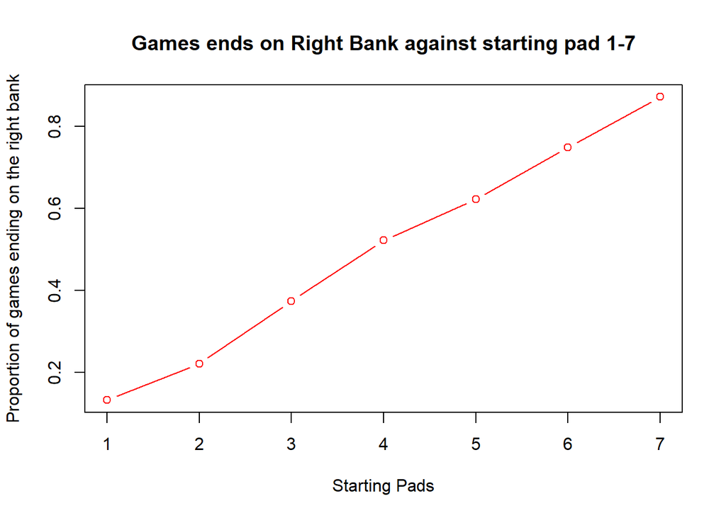

```r
#plot the graphs with "result_Q4"
plot_rb4b(results_Q4)
```

## 1.9 Question 4(c) Plot the mean number of hops against the starting pad.

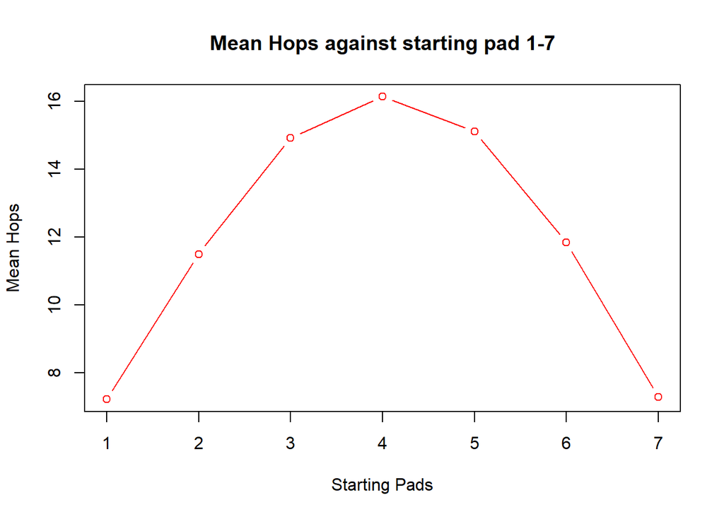

```r
plot_rb4c(results_Q4)
```

## 1.10 Question 4(d) Add error bars to both plots, showing 95% confidence intervals for the proportions and standard errors for the mean numbers of hops.

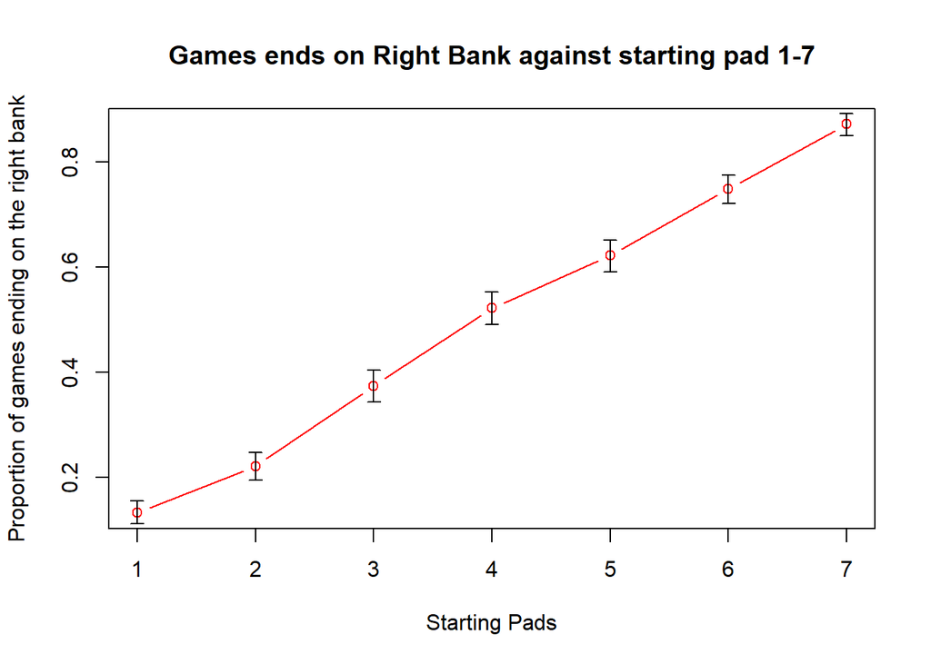

```r
#get CI values
lower_ci <- numeric(7)
upper_ci <- numeric(7)
#use the code of 3a again but loop it in 1-7
for (n in 1:7) {
  #finding 95% CI and Histogram
  nbankr <- sum(results_Q4[[n]]$banks == "right",na.rm = TRUE)
  n_total <- length(results_Q4[[n]]$banks)
  #using binomial testing with nbankr as x and ntotal as y
  ci<- binom.test(
    x = nbankr,
    n = n_total,
    conf.level = 0.95
  )

  lower_ci[n] = ci$conf.int[1]
  upper_ci[n] = ci$conf.int[2]

}
#plot graphs for proportions
plot_rb4b(results_Q4)
# Add 95% confidence interval error bars
arrows(
  x0 = 1:7,
  y0 = lower_ci,
  x1 = 1:7,
  y1 = upper_ci,
  angle = 90, code = 3, length = 0.05
)
```

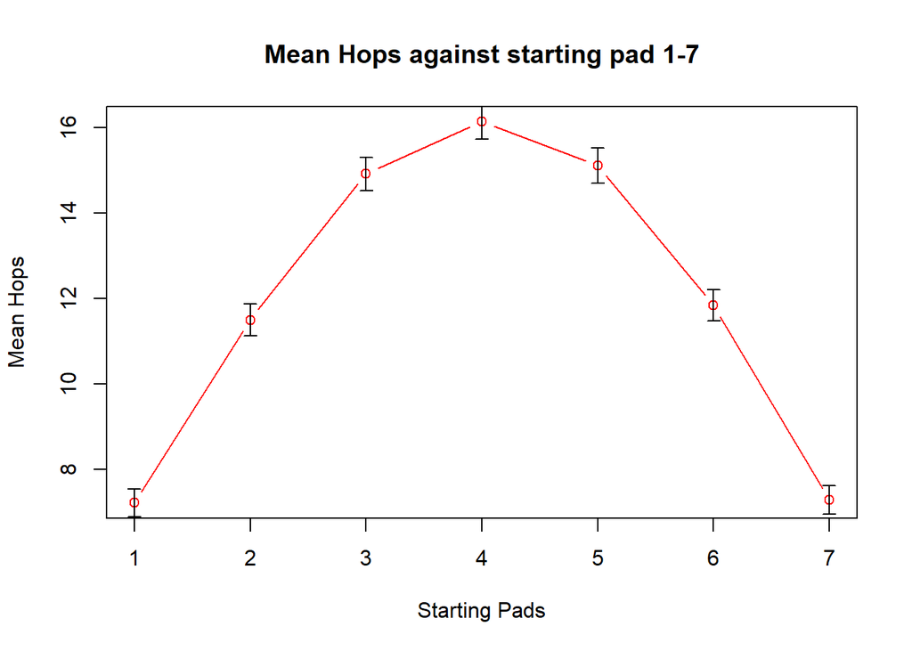

```r
#plot graphs for numbers of hops
#from 4(a) get values of mean hops and SD
mean_hops <- numeric(7)
sd_hops <- numeric(7)

for (n in 1:7){
  mean_hops[n]<-results_Q4[[n]]$frog_stats["mean_hops"]
  sd_hops[n]<- results_Q4[[n]]$frog_stats["sd_hops"]
}
#Calculate standard error for 1000 games
se_hops <- sd_hops / sqrt(1000)
#plot the graphs again
plot_rb4c(results_Q4)

# Add standard error bars
arrows(x0 = 1:7,
       y0 = mean_hops - se_hops,
       x1 = 1:7,
       y1 = mean_hops + se_hops,
       angle = 90,
       code = 3,
       length = 0.05)
```

## 1.11 Question 5 A windy day

## 1.12 5(a) Report the proportion of games ending on the right bank (with a 95% confidence interval) and the mean and standard deviation of the number of hops for both games.

```r
#Call Q3 equations with setting p_right to 0.7 as windy day
results_Q5 <- simulate_frogs(n_sims= 1000, p_right = 0.7)
#get comparison with fair day, and windy day
fair =results_Q3$frog_stats
windy =results_Q5$frog_stats

#set up function to compare ci for fair and windy
compare_ci <- list(results_Q3, results_Q5)
#set up vector for 2 ci
lower_ci <- numeric(2)
upper_ci <- numeric(2)
#loop through both cases
for (n in 1:2) {
  nbankr <- sum(compare_ci[[n]]$banks == "right", na.rm = TRUE)
  n_total <- length(compare_ci[[n]]$banks)

  ci <- binom.test(
    x = nbankr,
    n = n_total,
    conf.level = 0.95
  )

  lower_ci[n] <- ci$conf.int[1]
  upper_ci[n] <- ci$conf.int[2]
}
#return for values for comparison
fair
```

```
p_right_bank    mean_hops      sd_hops
     0.49800     15.29800     11.50598
```

```r
windy
```

```
p_right_bank    mean_hops      sd_hops
     0.97100      9.30800      6.35622
```

```r
# Display both ci of fair and windy
c(Fair_Lower = lower_ci[1],
  Fair_Upper = upper_ci[1],
  Windy_Lower = lower_ci[2],
  Windy_Upper = upper_ci[2])
```

```
 Fair_Lower  Fair_Upper Windy_Lower Windy_Upper
  0.4665553   0.5294565   0.9586153   0.9804941
```

## 1.13 5(b) Produce a plot comparing the distribution of the number of hops in the two games.

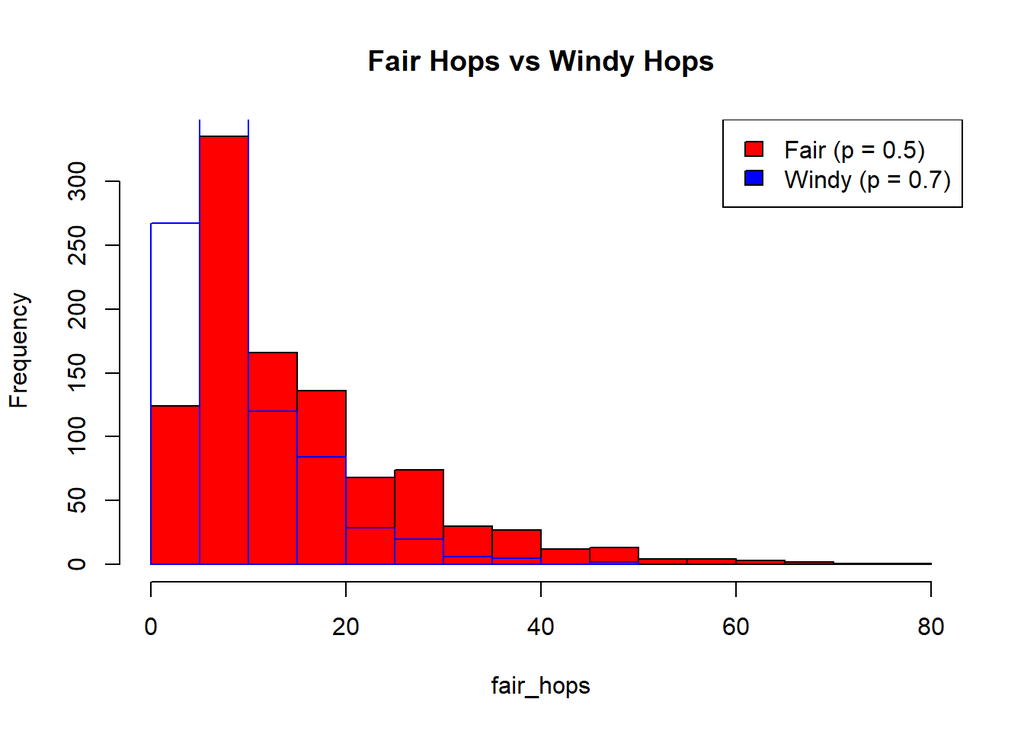

```r
#output hops_vector form both simulations
fair_hops <- results_Q3$hops_vector
windy_hops <- results_Q5$hops_vector
#list with histogram, while red is Fair game, blue border for Windy, preventing overlapping
hist(fair_hops,col= "red",main="Fair Hops vs Windy Hops")
hist(windy_hops,col = NA,border = "blue",add = TRUE)
#add legend for the histogram
legend("topright",
       legend = c("Fair (p = 0.5)", "Windy (p = 0.7)"),
       fill = c("red", "blue"))
```

## 1.14 5(c) Is the difference in the proportion of games ending on the right bank statistically significant? Use an appropriate test.

```r
#get values of ending with Right bank
fair_r <- sum(results_Q3$banks == "right", na.rm = TRUE)
windy_r <- sum(results_Q5$banks == "right", na.rm = TRUE)

#uses probability testing and T testing for fair days and windy days
test_Q5 <- prop.test(
  x = c(fair_r, windy_r),
  n = c(length(results_Q3$banks), length(results_Q5$banks))
)
t_test <- t.test(fair_hops, windy_hops)

# Display test results
test_Q5
```

```
    2-sample test for equality of proportions with continuity correction

data:  c(fair_r, windy_r) out of c(length(results_Q3$banks), length(results_Q5$banks))
X-squared = 571.21, df = 1, p-value < 2.2e-16
alternative hypothesis: two.sided
95 percent confidence interval:
 -0.5066882 -0.4393118
sample estimates:
prop 1 prop 2
 0.498  0.971
```

```r
t_test
```

```
    Welch Two Sample t-test

data:  fair_hops and windy_hops
t = 14.41, df = 1556.8, p-value < 2.2e-16
alternative hypothesis: true difference in means is not equal to 0
95 percent confidence interval:
 5.17465 6.80535
sample estimates:
mean of x mean of y
   15.298     9.308
```

## 1.15 5(d)Explain why the wind changes the results in the way you observe.

# 2 Data Analysis: Maternal Health Risk

```r
load("data/assess_data_1226.Rdata")
```

## 2.1 Question 6 Commenting and fixing code

## 2.2 6(a) Code Comment

```r
#load data set
load("data/assess_data_1226.Rdata")
#display structure of mh_data
str(mh_data)
#counting the duplicated age values
sum(duplicated(mh_data$age))
#getting a variable of risk_level is high
mh_data$high_risk <- mh_data$risk_level == "high"
#display a table with for high risk and non-high risk
table(mh_data$high_risk)
#box plot by high risk status
boxplot(bs ~ high_risk, data = mh_data)
#binomial regression glm, while argument high_risk is missing, re-add data=mh_data should work
fit <- glm(high_risk ~ bs + systolic_bp, family = binomial)
#summary of the binomial regression
summary(fit)
#calculate exponential result for the regression
exp(coef(fit))
#calculate CI for the coefficient coefficients, this should be changed to exp(confint.default(fit)) as its log odds coefficient instead of log ratios
or_ci <- confint.default(fit)
#display CI
or_ci
```

## 2.3 6(b) Updating Code

```r
#keep the same loading
load("data/assess_data_1226.Rdata")
#structure checking
str(mh_data)
```

```
'data.frame':   458 obs. of  9 variables:
 $ patient_id  : chr  "MH5252" "MH5094" "MH4126" "MH6433" ...
 $ site        : chr  "Clinic A" "Clinic B" "Clinic A" "Clinic B" ...
 $ age         : num  21 32 37 35 35 35 32 55 18 23 ...
 $ systolic_bp : num  120 120 120 120 100 100 120 140 85 100 ...
 $ diastolic_bp: num  80 90 90 60 70 70 90 100 60 85 ...
 $ bs          : num  7.5 7.9 11 6.1 6.9 7.8 7.8 18 7.5 6.9 ...
 $ body_temp   : num  98 98 98 98 98 98 0 98 101 98 ...
 $ heart_rate  : num  77 70 88 76 60 66 70 90 86 66 ...
 $ risk_level  : chr  "low risk" "low risk" "high risk" "mid risk" ...
```

```r
#if doing full data set duplicate checking, use "mh_data" instead of "mh_data$age"
sum(duplicated(mh_data))
```

```
[1] 6
```

```r
#rename the search from "high" to "high risk", the previous one is setting all result to FALSE
mh_data$high_risk <- mh_data$risk_level == "high risk"
table(mh_data$high_risk)
```

```
FALSE  TRUE
  344   114
```

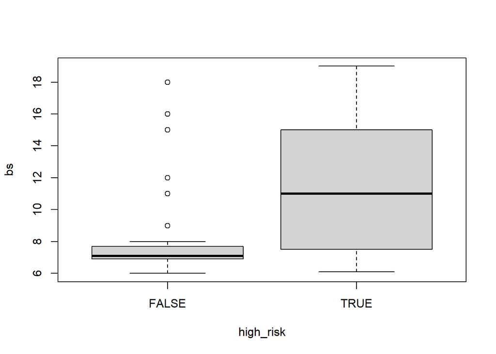

```r
boxplot(bs ~ high_risk, data = mh_data)
```

```r
#add "data=mh_data" to let r terminal to specify the dataset for the binomial regression
fit <- glm(high_risk ~ bs + systolic_bp, family = binomial, data=mh_data)
summary(fit)
```

```
Call:
glm(formula = high_risk ~ bs + systolic_bp, family = binomial,
    data = mh_data)

Coefficients:
             Estimate Std. Error z value Pr(>|z|)
(Intercept) -7.604348   0.999311  -7.610 2.75e-14 ***
bs           0.490917   0.064857   7.569 3.75e-14 ***
systolic_bp  0.020509   0.008152   2.516   0.0119 *
---
Signif. codes:  0 '***' 0.001 '**' 0.01 '*' 0.05 '.' 0.1 ' ' 1

(Dispersion parameter for binomial family taken to be 1)

    Null deviance: 514.00  on 457  degrees of freedom
Residual deviance: 367.83  on 455  degrees of freedom
AIC: 373.83

Number of Fisher Scoring iterations: 5
```

```r
exp(coef(fit))
```

```
 (Intercept)           bs  systolic_bp
0.0004982802 1.6338137033 1.0207205136
```

```r
or_ci <- exp(confint.default(fit))
or_ci
```

```
                   2.5 %     97.5 %
(Intercept) 7.028441e-05 0.00353255
bs          1.438787e+00 1.85527673
systolic_bp 1.004540e+00 1.03716114
```

## 2.4 Question 7 Before any modelling, perform a quality control check of the data set.

## 2.5 7(a) Data Checking before processing

```r
  #checking structure
  str(mh_data)
```

```
'data.frame':   458 obs. of  10 variables:
 $ patient_id  : chr  "MH5252" "MH5094" "MH4126" "MH6433" ...
 $ site        : chr  "Clinic A" "Clinic B" "Clinic A" "Clinic B" ...
 $ age         : num  21 32 37 35 35 35 32 55 18 23 ...
 $ systolic_bp : num  120 120 120 120 100 100 120 140 85 100 ...
 $ diastolic_bp: num  80 90 90 60 70 70 90 100 60 85 ...
 $ bs          : num  7.5 7.9 11 6.1 6.9 7.8 7.8 18 7.5 6.9 ...
 $ body_temp   : num  98 98 98 98 98 98 0 98 101 98 ...
 $ heart_rate  : num  77 70 88 76 60 66 70 90 86 66 ...
 $ risk_level  : chr  "low risk" "low risk" "high risk" "mid risk" ...
 $ high_risk   : logi  FALSE FALSE TRUE FALSE FALSE FALSE ...
```

```r
  #count duplicated record
  duplicates <- sum(duplicated(mh_data))
  print(duplicates)
```

```
[1] 6
```

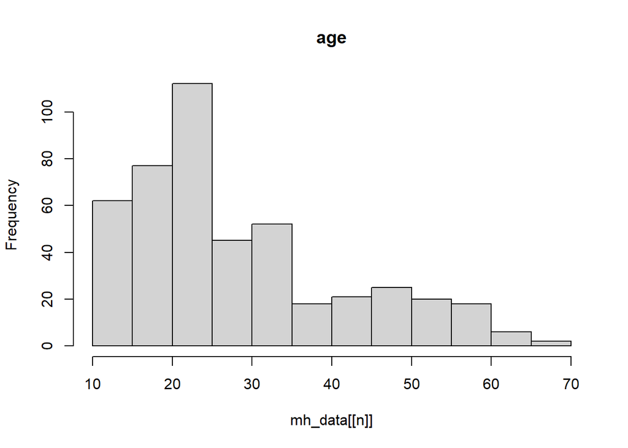

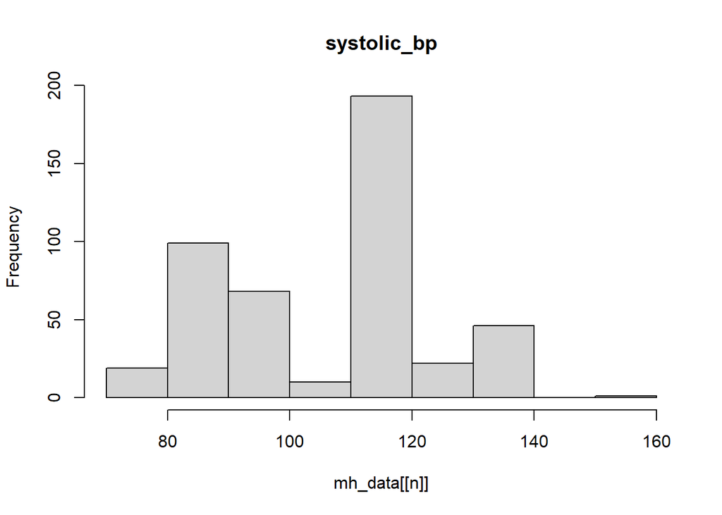

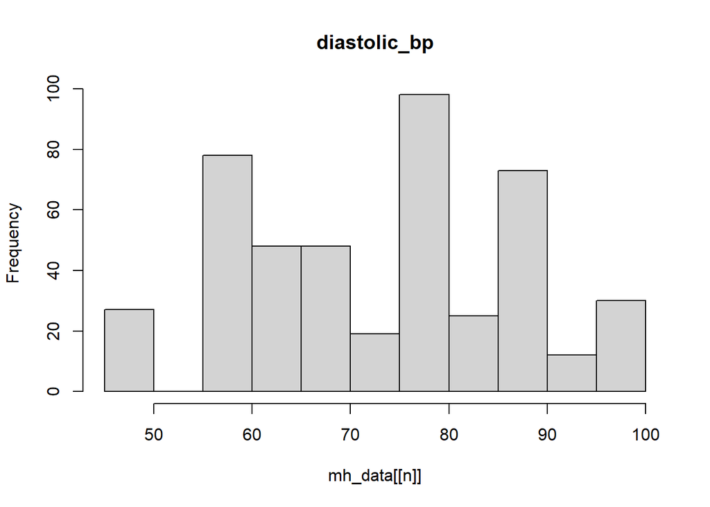

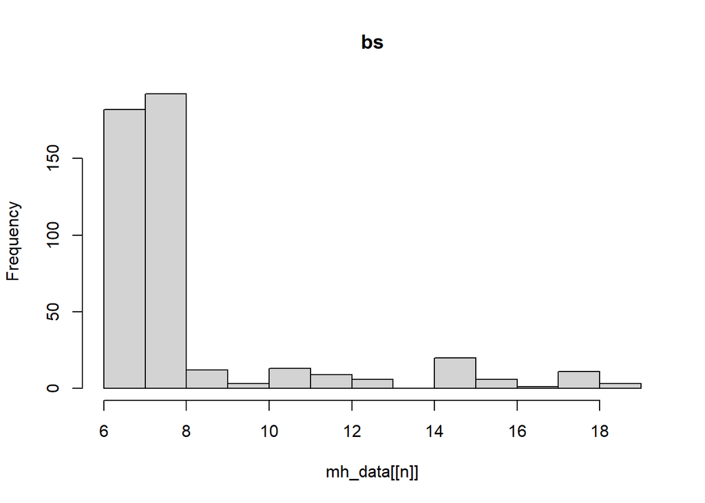

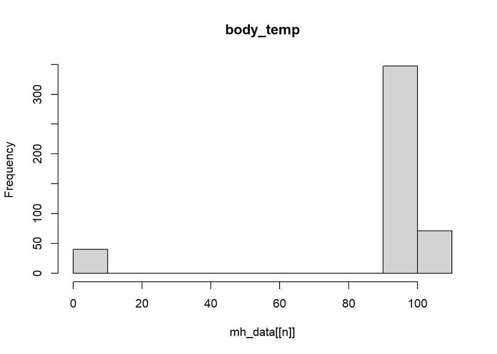

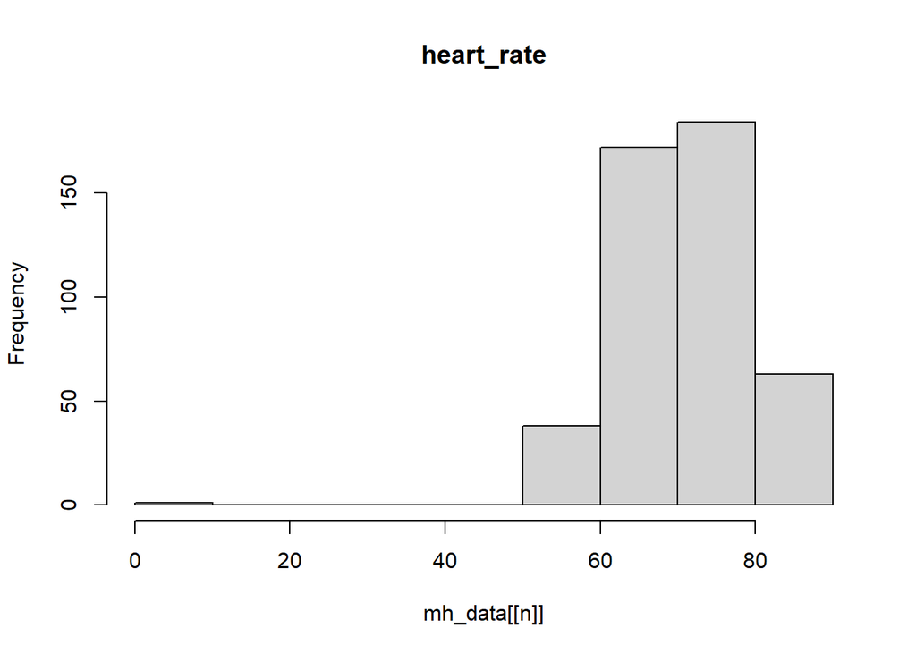

```r
  #displaying all variables for checking in a histogram
  vars<- c("age", "systolic_bp", "diastolic_bp", "bs", "body_temp","heart_rate")

  for (n in vars){
    hist(mh_data[[n]], main =n)
  }
```

```r
  summary(mh_data)
```

```
     patient_id         site          age         systolic_bp
 Length   :458   Length   :458   Min.   :10.00   Min.   : 70.0
 N.unique :452   N.unique :  3   1st Qu.:19.00   1st Qu.: 90.0
 N.blank  :  0   N.blank  :  0   Median :25.00   Median :120.0
 Min.nchar:  6   Min.nchar:  8   Mean   :29.19   Mean   :110.7
 Max.nchar:  6   Max.nchar:  8   3rd Qu.:35.00   3rd Qu.:120.0
                                 Max.   :70.00   Max.   :160.0
  diastolic_bp         bs           body_temp        heart_rate
 Min.   : 49.0   Min.   : 6.000   Min.   :  0.00   Min.   : 7.00
 1st Qu.: 65.0   1st Qu.: 6.900   1st Qu.: 98.00   1st Qu.:70.00
 Median : 80.0   Median : 7.500   Median : 98.00   Median :76.00
 Mean   : 75.5   Mean   : 8.344   Mean   : 90.05   Mean   :73.92
 3rd Qu.: 88.0   3rd Qu.: 7.900   3rd Qu.: 98.00   3rd Qu.:80.00
 Max.   :100.0   Max.   :19.000   Max.   :103.00   Max.   :90.00
     risk_level  high_risk
 Length   :458   Mode :logical
 N.unique :  3   FALSE:344
 N.blank  :  0   TRUE :114
 Min.nchar:  8
 Max.nchar:  9
```

## 2.6 7(b) Calling function “clean_maternal”

```r
data_cleaned<-clean_maternal(mh_data)
```

```
Removed duplicates: 6
Non Physiologically Plausible Data Removed: 40
```

```r
data_cleaned
```

```
    patient_id     site age systolic_bp diastolic_bp    bs body_temp heart_rate
1       MH5252 Clinic A  21         120           80  7.50      98.0         77
2       MH5094 Clinic B  32         120           90  7.90      98.0         70
3       MH4126 Clinic A  37         120           90 11.00      98.0         88
4       MH6433 Clinic B  35         120           60  6.10      98.0         76
5       MH9656 Clinic B  35         100           70  6.90      98.0         60
6       MH4580 Clinic B  35         100           70  7.80      98.0         66
8       MH7361 Clinic B  55         140          100 18.00      98.0         90
9       MH9405 Clinic C  18          85           60  7.50     101.0         86
10      MH5323 Clinic A  23         100           85  6.90      98.0         66
11      MH3625 Clinic B  29         100           70  6.80      98.0         80
12      MH8144 Clinic A  40         120           95 11.00      98.0         80
13      MH3298 Clinic B  12          95           60  6.90      98.0         65
14      MH3332 Clinic B  50         120           80  7.70      98.0         70
15      MH4812 Clinic B  22         100           65  7.80      98.0         80
```

[output cut: 811 more lines]

```r
#double checking for data_cleaned, with structure, and double check duplicated data, or with values 0 in heart_rate and body_temp
str(data_cleaned)
```

```
'data.frame':   412 obs. of  10 variables:
 $ patient_id  : chr  "MH5252" "MH5094" "MH4126" "MH6433" ...
 $ site        : Factor w/ 3 levels "Clinic A","Clinic B",..: 1 2 1 2 2 2 2 3 1 2 ...
 $ age         : num  21 32 37 35 35 35 55 18 23 29 ...
 $ systolic_bp : num  120 120 120 120 100 100 140 85 100 100 ...
 $ diastolic_bp: num  80 90 90 60 70 70 100 60 85 70 ...
 $ bs          : num  7.5 7.9 11 6.1 6.9 7.8 18 7.5 6.9 6.8 ...
 $ body_temp   : num  98 98 98 98 98 98 98 101 98 98 ...
 $ heart_rate  : num  77 70 88 76 60 66 90 86 66 80 ...
 $ risk_level  : Factor w/ 3 levels "high risk","low risk",..: 2 2 1 3 2 2 1 3 3 2 ...
 $ high_risk   : logi  FALSE FALSE TRUE FALSE FALSE FALSE ...
```

```r
sum(duplicated(data_cleaned))
```

```
[1] 0
```

```r
sum(data_cleaned$body_temp == 0, na.rm = TRUE)
```

```
[1] 0
```

```r
sum(data_cleaned$heart_rate == 0, na.rm = TRUE)
```

```
[1] 0
```

## 2.7 Question 8 Blood glucose and high risk

## 2.8 Q8(a) Box plot comparing bs between high risk and other patients

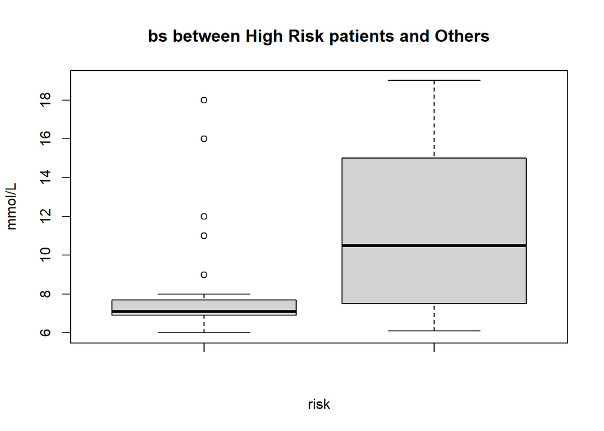

```r
#get data high_risk patient's bs values
highbs <- data_cleaned$bs[data_cleaned$high_risk==TRUE]
#get others bs values
otherbs <- data_cleaned$bs[data_cleaned$high_risk==FALSE]

#using box plot here for the exact comparison
boxplot(otherbs, highbs,main= "bs between High Risk patients and Others", xlab="risk", ylab="mmol/L")
```

## 2.9 Q8 (b) Welch T testing

```r
#getting summary of bs values for both group patients and the number of each group
summary(highbs)
```

```
   Min. 1st Qu.  Median    Mean 3rd Qu.    Max.
   6.10    7.55   10.50   11.12   15.00   19.00
```

```r
summary(otherbs)
```

```
   Min. 1st Qu.  Median    Mean 3rd Qu.    Max.
   6.00    6.90    7.10    7.39    7.70   18.00
```

```r
length(highbs)
```

```
[1] 102
```

```r
length(otherbs)
```

```
[1] 310
```

```r
#Welch t test for both groups, using both mean is the same as null hypnosis
t.test(highbs, otherbs)
```

```
    Welch Two Sample t-test

data:  highbs and otherbs
t = 9.3499, df = 108.86, p-value = 1.314e-15
alternative hypothesis: true difference in means is not equal to 0
95 percent confidence interval:
 2.939054 4.520296
sample estimates:
mean of x mean of y
11.119804  7.390129
```

## 2.10 8(c) Plotting with glm()

```r
#fitting logistic model with glm()
fit <- glm(high_risk ~ bs, family = binomial, data=data_cleaned)
summary(fit)
```

```
Call:
glm(formula = high_risk ~ bs, family = binomial, data = data_cleaned)

Coefficients:
            Estimate Std. Error z value Pr(>|z|)
(Intercept)  -5.8387     0.5973  -9.775  < 2e-16 ***
bs            0.5565     0.0715   7.784 7.04e-15 ***
---
Signif. codes:  0 '***' 0.001 '**' 0.01 '*' 0.05 '.' 0.1 ' ' 1

(Dispersion parameter for binomial family taken to be 1)

    Null deviance: 461.15  on 411  degrees of freedom
Residual deviance: 332.49  on 410  degrees of freedom
AIC: 336.49

Number of Fisher Scoring iterations: 5
```

```r
exp(coef(fit))
```

```
(Intercept)          bs
0.002912697 1.744609001
```

```r
or_ci <- exp(confint.default(fit))
or_ci
```

```
                   2.5 %      97.5 %
(Intercept) 0.0009033997 0.009390975
bs          1.5164858075 2.007048502
```

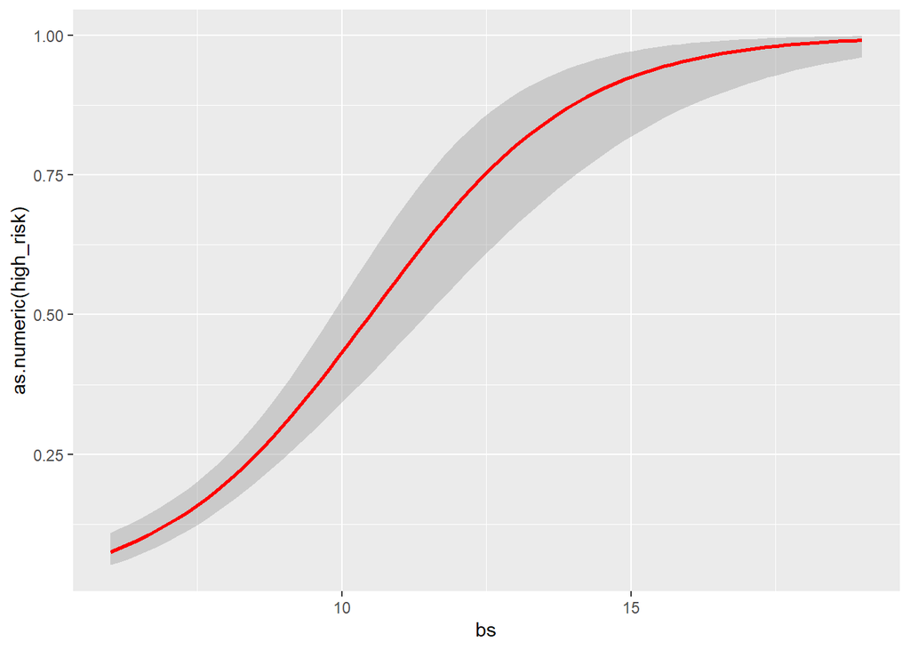

```r
#Plot the observed data (high risk as 0/1) against blood glucose and add the fitted logistic regression curve
ggplot(data_cleaned, aes(x= bs, y= as.numeric(high_risk)))+
  geom_smooth(method = "glm", method.args = list(family = binomial),colour = "red")
```

## 2.11 Question 9 Multiple logistic regression

## 2.12 9(a) Getting all 6 numeric measurements and site as covariates

```r
#get all 6 numeric measurements and site as covariates
fit_Q9 <- glm(high_risk ~ age+ systolic_bp+ diastolic_bp+ bs+ body_temp+ heart_rate+ site,
              family = binomial, data = data_cleaned)

summary(fit_Q9)
```

```
Call:
glm(formula = high_risk ~ age + systolic_bp + diastolic_bp +
    bs + body_temp + heart_rate + site, family = binomial, data = data_cleaned)

Coefficients:
              Estimate Std. Error z value Pr(>|z|)
(Intercept)  -72.49848   10.85567  -6.678 2.42e-11 ***
age           -0.01347    0.01517  -0.888   0.3746
systolic_bp    0.03017    0.01471   2.051   0.0402 *
diastolic_bp   0.02656    0.01876   1.416   0.1569
bs             0.54734    0.07968   6.870 6.44e-12 ***
body_temp      0.59928    0.10214   5.867 4.43e-09 ***
heart_rate     0.03079    0.02002   1.538   0.1241
siteClinic B   0.05565    0.35806   0.155   0.8765
siteClinic C   0.10641    0.40460   0.263   0.7925
---
Signif. codes:  0 '***' 0.001 '**' 0.01 '*' 0.05 '.' 0.1 ' ' 1

(Dispersion parameter for binomial family taken to be 1)

    Null deviance: 461.15  on 411  degrees of freedom
Residual deviance: 279.70  on 403  degrees of freedom
AIC: 297.7

Number of Fisher Scoring iterations: 5
```

## 2.13 9(b) Fit the same model to the uncleaned data

```r
#load the mh data for original data
og_data <- mh_data
#add high risk to the table
og_data$high_risk <- og_data$risk_level == "high risk"
#fitting the same model to the original data
og_fit <- glm(high_risk ~ age+ systolic_bp+ diastolic_bp+ bs+ body_temp+ heart_rate+ site,
              family = binomial, data = og_data)

og_fit
```

```
Call:  glm(formula = high_risk ~ age + systolic_bp + diastolic_bp +
    bs + body_temp + heart_rate + site, family = binomial, data = og_data)

Coefficients:
 (Intercept)           age   systolic_bp  diastolic_bp            bs
  -12.624554     -0.025794      0.022985      0.010719      0.527755
   body_temp    heart_rate  siteClinic B  siteClinic C
    0.004748      0.051631      0.079247      0.188686

Degrees of Freedom: 457 Total (i.e. Null);  449 Residual
Null Deviance:      514
Residual Deviance: 354.3    AIC: 372.3
```

```r
og_fit
```

```
Call:  glm(formula = high_risk ~ age + systolic_bp + diastolic_bp +
    bs + body_temp + heart_rate + site, family = binomial, data = og_data)

Coefficients:
 (Intercept)           age   systolic_bp  diastolic_bp            bs
  -12.624554     -0.025794      0.022985      0.010719      0.527755
   body_temp    heart_rate  siteClinic B  siteClinic C
    0.004748      0.051631      0.079247      0.188686

Degrees of Freedom: 457 Total (i.e. Null);  449 Residual
Null Deviance:      514
Residual Deviance: 354.3    AIC: 372.3
```

```r
fit_Q9
```

```
Call:  glm(formula = high_risk ~ age + systolic_bp + diastolic_bp +
    bs + body_temp + heart_rate + site, family = binomial, data = data_cleaned)

Coefficients:
 (Intercept)           age   systolic_bp  diastolic_bp            bs
   -72.49848      -0.01347       0.03017       0.02656       0.54734
   body_temp    heart_rate  siteClinic B  siteClinic C
     0.59928       0.03079       0.05565       0.10641

Degrees of Freedom: 411 Total (i.e. Null);  403 Residual
Null Deviance:      461.2
Residual Deviance: 279.7    AIC: 297.7
```

## 2.14 9(c) Model Selection